# bootcamp

Shoshana Rapley

2025-02-10

# Statistical analysis: reinforcers

Instead of using dyad connections, we can use the social groups (which are serendipitously nearly evenly split among the reinforcers) to ask questions about conspecific interactions. Social groups can tell you more about the overall social environment than dyads alone (Farine and Whitehal 2015).

We hypothesised members of the mixed resident-reinforcer social group would proceed more quickly through the PRBM phases than those in the reinforcer only group. I also want to compare both reinforcer groups to the residents to see if one is more similar than the other.

Dates are from the last reinforcer released to the first reinforcer translocated to the secondary site.

```r
# social group membership
club <- c("Rowan", "Rory", "Fauna", "Zeus", "Rocky", "Sofi", "Loki", "Avery", "Maeve")

# define reinforcer date period
rein_dates <- seq.Date(from = as_date("2023-06-11"), to = as_date("2023-08-05"), by = "day")
```

### m1: Distance moved

Does daily distance moved differ between the social groups?

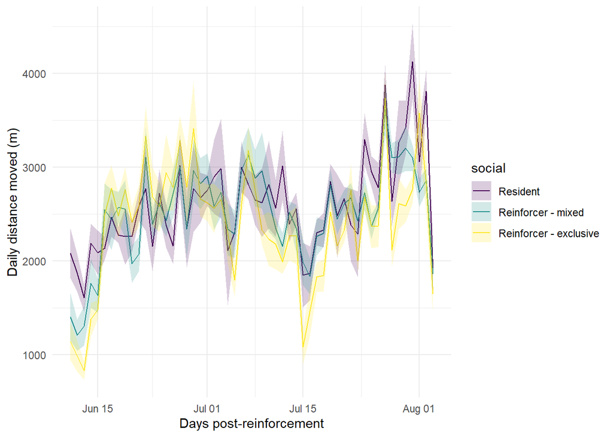

```r
# read in data and filter to reinforcement period
datam1 <- read.csv("results/daily_distance_moved.csv") %>%
  # add metadata
  left_join(dplyr::select(metadata, c("id", "cohort"))) %>%
  # format dates as dates
  mutate(date = as_date(date_bird)) %>%
  # limit to reinforcement period
  filter(date %in% rein_dates) %>%
  # add a time elapsed post-release variable
  mutate(elapsed = as.numeric(date - as_date("2023-06-10"))) %>%
  # add column for membership to social group
  mutate(social = ifelse(id %in% club, "Reinforcer - exclusive", ifelse(cohort == "Resident", "Resident", "Reinforcer - mixed"))) %>%
  # convert group to factor and set resident as the intercept
  mutate(social = factor(social, levels = c("Resident", "Reinforcer - mixed", "Reinforcer - exclusive")))

# create social group means
sum1 <- datam1 %>%
  group_by(date, social) %>%
  summarise(dist = mean(daily_dist),
            upper = dist + std.error(daily_dist),
            lower = dist - std.error(daily_dist)) %>%
  arrange(date)

# plot daily distance over time as social group means
ggplot(sum1, aes(date, dist, ymin = lower, ymax = upper)) +
  geom_path(aes(colour = social)) +
  geom_ribbon(aes(fill = social), alpha = 0.2) +
  xlab("Days post-reinforcement") +
  ylab("Daily distance moved (m)") +
  theme_minimal() +
  scale_fill_viridis_d()+
  scale_colour_viridis_d()
```

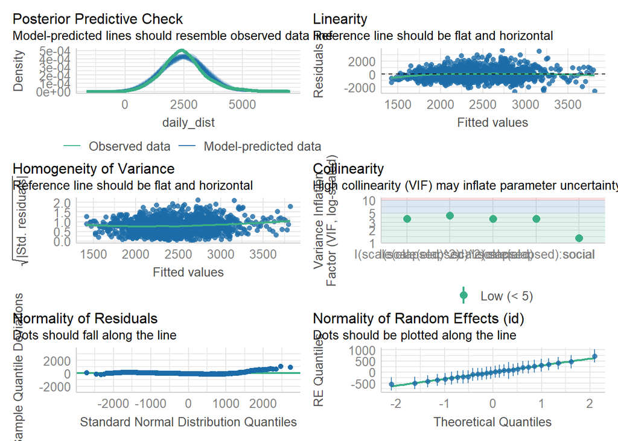

```r
# test difference between the groups with interaction of time as a quadratic
m1 <- glmmTMB(daily_dist ~ social * (scale(elapsed) + I(scale(elapsed)^2)) + (1|id),
              data = datam1,
              na.action = "na.fail")

# model selection
dm1 <- dredge(m1)

# parsimonious model where delta <2 and fewest predictors
# in this case only one model (the top ranked) delta AICc < 2
best1 <- get.models(dm1, delta == 0)[[1]]

# check model
check_model(best1)
```

```r
# summary
summary(best1)
```

```
##  Family: gaussian  ( identity )
## Formula:          daily_dist ~ scale(elapsed) + I(scale(elapsed)^2) + social +
##     (1 | id) + scale(elapsed):social + I(scale(elapsed)^2):social
## Data: datam1
##
##      AIC      BIC   logLik deviance df.resid
##  23708.5  23766.6 -11843.3  23686.5     1445
##
## Random effects:
##
## Conditional model:
##  Groups   Name        Variance Std.Dev.
##  id       (Intercept) 100587   317.2
##  Residual             652340   807.7
## Number of obs: 1456, groups:  id, 28
##
## Dispersion estimate for gaussian family (sigma^2): 6.52e+05
##
## Conditional model:
##                                                  Estimate Std. Error z value
## (Intercept)                                      2594.219    129.620  20.014
## scale(elapsed)                                    277.754     41.188   6.743
## I(scale(elapsed)^2)                                 5.559     45.777   0.121
## socialReinforcer - mixed                           71.587    168.691   0.424
## socialReinforcer - exclusive                      -67.041    176.062  -0.381
## scale(elapsed):socialReinforcer - mixed           -35.014     53.553  -0.654
## scale(elapsed):socialReinforcer - exclusive      -154.483     55.180  -2.800
## I(scale(elapsed)^2):socialReinforcer - mixed     -158.597     59.342  -2.673
## I(scale(elapsed)^2):socialReinforcer - exclusive -150.974     61.461  -2.456
##                                                  Pr(>|z|)
## (Intercept)                                       < 2e-16 ***
## scale(elapsed)                                   1.55e-11 ***
## I(scale(elapsed)^2)                               0.90334
## socialReinforcer - mixed                          0.67130
## socialReinforcer - exclusive                      0.70337
## scale(elapsed):socialReinforcer - mixed           0.51323
## scale(elapsed):socialReinforcer - exclusive       0.00512 **
## I(scale(elapsed)^2):socialReinforcer - mixed      0.00753 **
## I(scale(elapsed)^2):socialReinforcer - exclusive  0.01403 *
## ---
## Signif. codes:  0 '***' 0.001 '**' 0.01 '*' 0.05 '.' 0.1 ' ' 1
```

```r
# post-hoc comparison of slopes
emtrends(best1, pairwise ~ social, var = "elapsed")
```

```
## $emtrends
##  social                 elapsed.trend   SE   df lower.CL upper.CL
##  Resident                       17.81 2.64 1445    12.63     23.0
##  Reinforcer - mixed             15.57 2.20 1445    11.26     19.9
##  Reinforcer - exclusive          7.91 2.36 1445     3.29     12.5
##
## Confidence level used: 0.95
##
## $contrasts
##  contrast                                        estimate   SE   df t.ratio
##  Resident - (Reinforcer - mixed)                     2.25 3.43 1445   0.654
##  Resident - (Reinforcer - exclusive)                 9.91 3.54 1445   2.800
##  (Reinforcer - mixed) - (Reinforcer - exclusive)     7.66 3.22 1445   2.380
##  p.value
##   0.7902
##   0.0143
##   0.0459
##
## P value adjustment: tukey method for comparing a family of 3 estimates
```

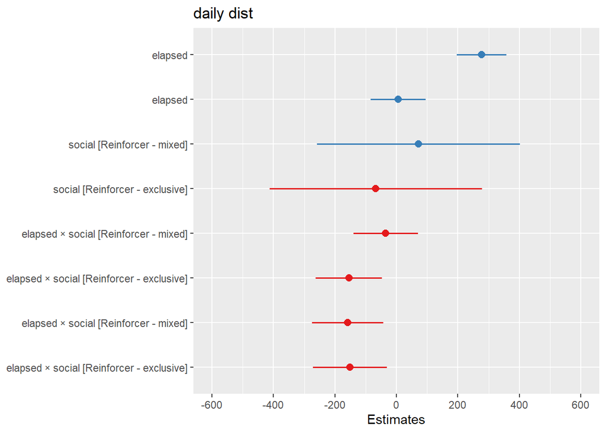

```r
# plot effects
plot_model(best1)
```

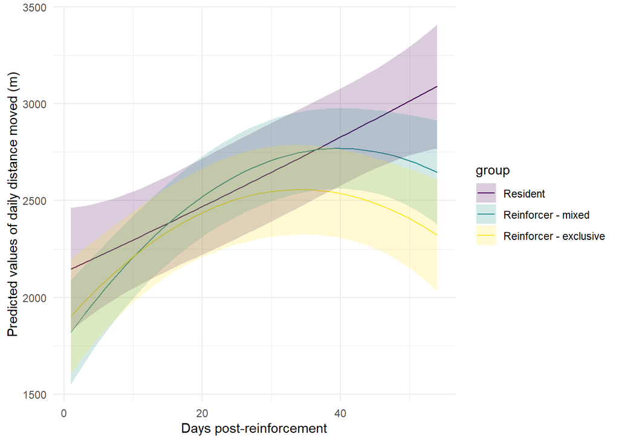

```r
# marginal effects
pred1 <- predict_response(best1, terms = c("elapsed [all]", "social"))

# plot predictions
ggplot(pred1, aes(x, predicted, fill = group, ymin = conf.low, ymax = conf.high)) +
  geom_line(aes(colour = group))+
  geom_ribbon(alpha = 0.2)+
  xlab("Days post-reinforcement") +
  ylab("Predicted values of daily distance moved (m)") +
  theme_minimal()+
  scale_fill_viridis_d()+
  scale_colour_viridis_d()
```

**Results:** The best fitting model included social group and time (linear and quadratic), the interaction between these, and individual as a random effect.

Distance moved per day increased with time post-release (estimate: 277.75 ± 41.19 SE, p < 0.001). Both reinforcer groups had significant negative quadratic responses over time compared to residents, meaning the increase of distance over time decelerated.

The exclusive reinforcer group had a significantly lower slope of movement increase over time compared to the residents (p = 0.0143) and weakly lower compared to the mixed reinforcers (p=0.0459).

**Interpretation:** Reinforcers increase over time in response to the need to explore (find resources etc.) then stabilising - evidence of establishment.

Also increase in movement may align with theoretical increase in fitness and physical capability with increased time out of captivity.

Movement by the residents might be influenced by factors unrelated to settlement.

### m2: Roost fidelity

Does distance between roosts differ between the social groups?

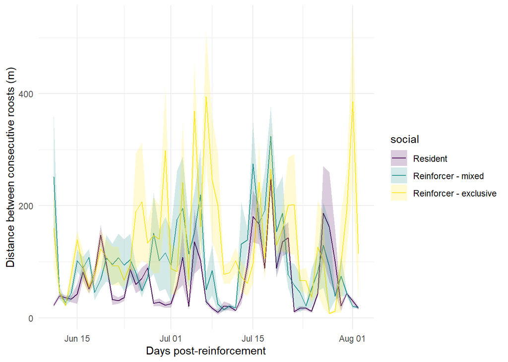

```r
# read in data and filter to reinforcement period
datam2 <- read.csv("results/daily_distance_between_roosts.csv") %>%
  # add metadata
  left_join(dplyr::select(metadata, c("id", "cohort"))) %>%
  # format dates as dates
  mutate(date = as_date(date)) %>%
  # limit to reinforcement period
  filter(date %in% rein_dates) %>%
  # add a time elapsed post-release variable and scale it
  mutate(elapsed = as.numeric(date - as_date("2023-06-10"))) %>%
  # add column for membership to social group
  mutate(social = ifelse(id %in% club, "Reinforcer - exclusive", ifelse(cohort == "Resident", "Resident", "Reinforcer - mixed"))) %>%
  # convert group to factor and set resident as the intercept
  mutate(social = factor(social, levels = c("Resident", "Reinforcer - mixed", "Reinforcer - exclusive")))

# create social group means
sum2 <- datam2 %>%
  group_by(date, social) %>%
  summarise(dist = mean(distance_previous),
            upper = dist + std.error(distance_previous),
            lower = dist - std.error(distance_previous)) %>%
  arrange(date)

# plot roost displacement over time as social group means
ggplot(sum2, aes(date, dist, ymin = lower, ymax = upper)) +
  geom_path(aes(colour = social)) +
  geom_ribbon(aes(fill = social), alpha = 0.2) +
  xlab("Days post-reinforcement") +
  ylab("Distance between consecutive roosts (m)") +
  theme_minimal() +
  scale_fill_viridis_d()+
  scale_colour_viridis_d()
```

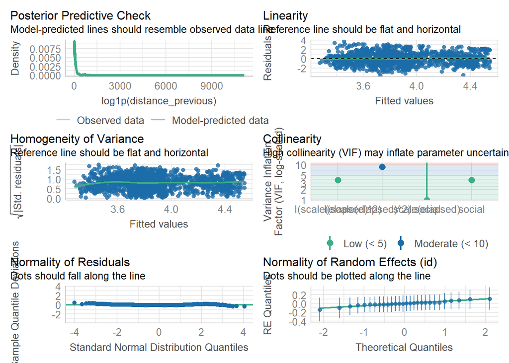

```r
# test difference between the groups with interaction of time as a quadratic
m2 <- glmmTMB(log1p(distance_previous) ~ social * (scale(elapsed) + I(scale(elapsed)^2)) + (1|id),
              data = datam2,
              na.action = "na.fail")

# model selection
dm2 <- dredge(m2)

# parsimonious model where delta <2 and fewest predictors
#  in this case only one model (the top ranked) delta AICc < 2
best2 <- get.models(dm2, delta == 0)[[1]]

# check model
check_model(best2)
```

```r
# summary
summary(best2)
```

```
##  Family: gaussian  ( identity )
## Formula:
## log1p(distance_previous) ~ scale(elapsed) + I(scale(elapsed)^2) +
##     social + (1 | id) + I(scale(elapsed)^2):social
## Data: datam2
##
##      AIC      BIC   logLik deviance df.resid
##   4569.0   4616.3  -2275.5   4551.0     1414
##
## Random effects:
##
## Conditional model:
##  Groups   Name        Variance Std.Dev.
##  id       (Intercept) 0.01009  0.1004
##  Residual             1.42512  1.1938
## Number of obs: 1423, groups:  id, 28
##
## Dispersion estimate for gaussian family (sigma^2): 1.43
##
## Conditional model:
##                                                  Estimate Std. Error z value
## (Intercept)                                       3.72912    0.09961   37.44
## scale(elapsed)                                   -0.10131    0.03177   -3.19
## I(scale(elapsed)^2)                              -0.07244    0.06829   -1.06
## socialReinforcer - mixed                          0.17756    0.12851    1.38
## socialReinforcer - exclusive                      0.71211    0.13326    5.34
## I(scale(elapsed)^2):socialReinforcer - mixed     -0.04067    0.08876   -0.46
## I(scale(elapsed)^2):socialReinforcer - exclusive -0.21496    0.09176   -2.34
##                                                  Pr(>|z|)
## (Intercept)                                       < 2e-16 ***
## scale(elapsed)                                    0.00143 **
## I(scale(elapsed)^2)                               0.28875
## socialReinforcer - mixed                          0.16707
## socialReinforcer - exclusive                      9.1e-08 ***
## I(scale(elapsed)^2):socialReinforcer - mixed      0.64680
## I(scale(elapsed)^2):socialReinforcer - exclusive  0.01915 *
## ---
## Signif. codes:  0 '***' 0.001 '**' 0.01 '*' 0.05 '.' 0.1 ' ' 1
```

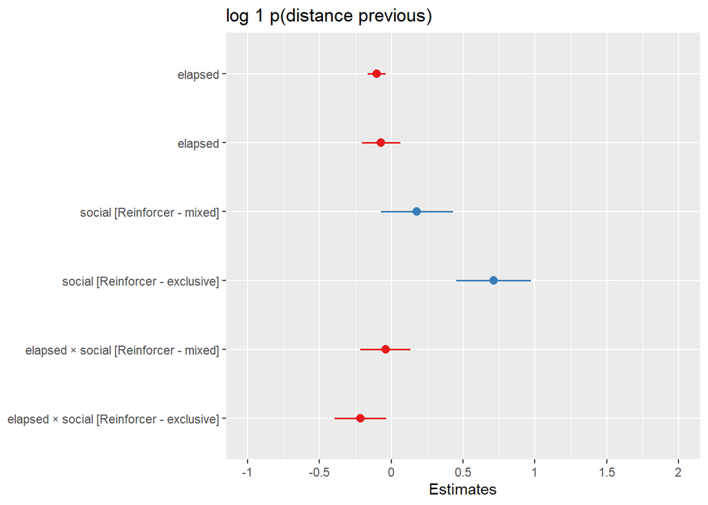

```r
# plot effects
plot_model(best2)
```

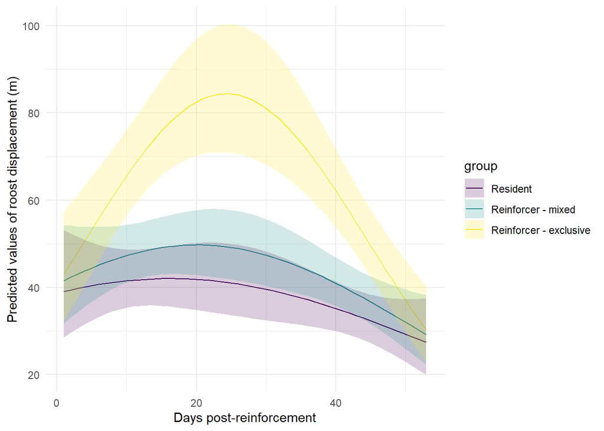

```r
# marginal effects
pred2 <- predict_response(best2, terms = c("elapsed [all]", "social"))

# plot predictions
ggplot(pred2, aes(x, predicted, fill = group, ymin = conf.low, ymax = conf.high)) +
  geom_line(aes(colour = group))+
  geom_ribbon(alpha = 0.2)+
  xlab("Days post-reinforcement") +
  ylab("Predicted values of roost displacement (m)") +
  theme_minimal()+
  scale_fill_viridis_d()+
  scale_colour_viridis_d()
```

**Results:** The best fitting model included social group, time (linear and quadratic), the interaction between these (only quadratic) and individual as a random effect.

Roost displacement generally decreased over time (estimate: -0.101 ± 0.032, p = 0.0014). However, this effect was mediated by social group, where exclusive reinforcers moved significantly further than residents (estimate: 0.71 ± 0.13, p < 0.001) and had a significant quadratic interaction (estimate: -0.21496 ± 0.09176, p = 0.01915) such that they initially increased before reaching a peak and declining.

The mixed reinforcers were not significantly different from residents.

**Interpretation:** Distance between consecutive roosts is a metric for home range establishment in space. Shorter distances between consecutive roosts indicate an individual is staying within a patch and building up familiarity in the roost locations; whereas large distances between consecutive roosts indicate continued searching or lack of stability.

Group co-membership with residents improved roost establishment and fidelity. This could be due to signalling good habitat, thereby reducing the need to explore additional roost sites, or due to social bonds.

Whereas the exclusive group showed a more “conventional” trend, of initial increase (with exploration) before declining (exploitation).

### m3: Release site fidelity

Does distance from the release site differ between the social groups?

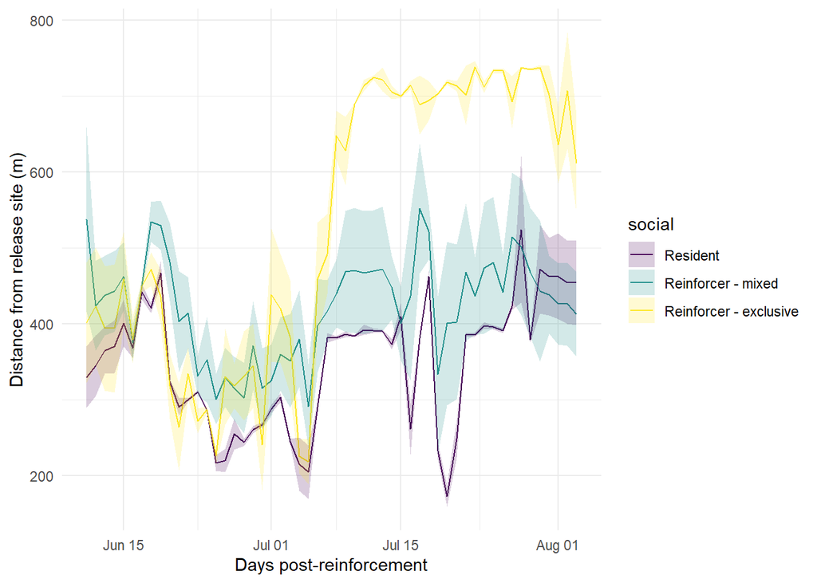

```r
# read in data and filter to reinforcement period
datam3 <- read.csv("results/daily_roost_distance_from_release.csv") %>%
  # add metadata
  left_join(dplyr::select(metadata, c("id", "cohort"))) %>%
  # format dates as dates
  mutate(date = as_date(date)) %>%
  # limit to reinforcement period
  filter(date %in% rein_dates) %>%
  # add a time elapsed post-release variable
  mutate(elapsed = as.numeric(date - as_date("2023-06-10"))) %>%
  # add column for membership to social group
  mutate(social = ifelse(id %in% club, "Reinforcer - exclusive", ifelse(cohort == "Resident", "Resident", "Reinforcer - mixed"))) %>%
  # convert group to factor and set resident as the intercept
  mutate(social = factor(social, levels = c("Resident", "Reinforcer - mixed", "Reinforcer - exclusive")))

# create social group means
sum3 <- datam3 %>%
  group_by(date, social) %>%
  summarise(dist = mean(dist_release),
            upper = dist + std.error(dist_release),
            lower = dist - std.error(dist_release)) %>%
  arrange(date)

# plot distance from release site over time as social group means
ggplot(sum3, aes(date, dist, ymin = lower, ymax = upper)) +
  geom_path(aes(colour = social)) +
  geom_ribbon(aes(fill = social), alpha = 0.2) +
  xlab("Days post-reinforcement") +
  ylab("Distance from release site (m)") +
  theme_minimal() +
  scale_fill_viridis_d()+
  scale_colour_viridis_d()
```

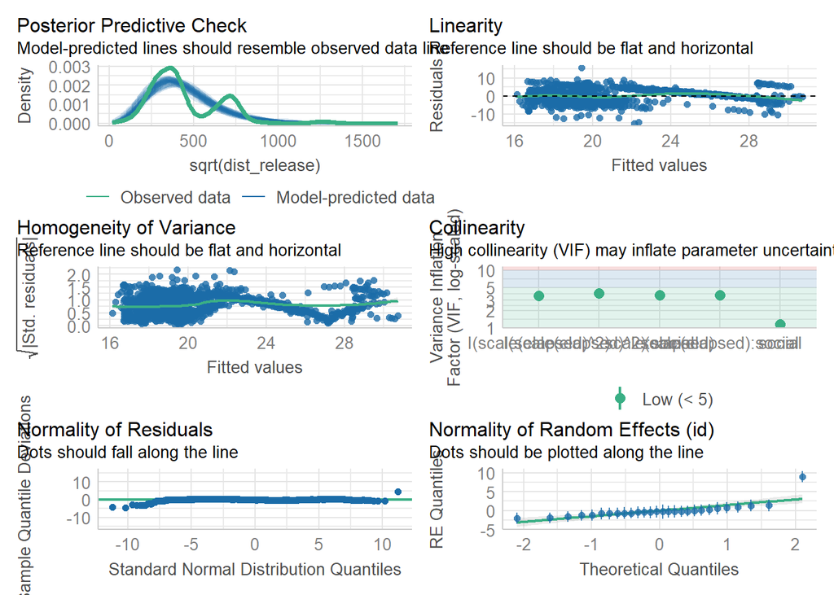

```r
# test difference between the groups with interaction of time as a quadratic
m3 <- glmmTMB(sqrt(dist_release) ~ social * (scale(elapsed) + I(scale(elapsed)^2)) + (1|id),
              data = datam3,
              na.action = "na.fail")

# model selection
dm3 <- dredge(m3)

# parsimonious model where delta <2 and fewest predictors
# in this case there was only one model (the top ranked) with delta <2
best3 <- get.models(dm3, delta ==0)[[1]]

# check model
check_model(best3)
```

```r
# summary
summary(best3)
```

```
##  Family: gaussian  ( identity )
## Formula:
## sqrt(dist_release) ~ scale(elapsed) + I(scale(elapsed)^2) + social +
##     (1 | id) + scale(elapsed):social + I(scale(elapsed)^2):social
## Data: datam3
##
##      AIC      BIC   logLik deviance df.resid
##   7687.1   7745.2  -3832.6   7665.1     1435
##
## Random effects:
##
## Conditional model:
##  Groups   Name        Variance Std.Dev.
##  id       (Intercept)  3.862   1.965
##  Residual             11.093   3.331
## Number of obs: 1446, groups:  id, 28
##
## Dispersion estimate for gaussian family (sigma^2): 11.1
##
## Conditional model:
##                                                  Estimate Std. Error z value
## (Intercept)                                       17.2273     0.7451  23.120
## scale(elapsed)                                     0.6600     0.1704   3.874
## I(scale(elapsed)^2)                                1.2086     0.1883   6.419
## socialReinforcer - mixed                           2.2016     0.9746   2.259
## socialReinforcer - exclusive                       4.7937     1.0178   4.710
## scale(elapsed):socialReinforcer - mixed           -0.3700     0.2218  -1.668
## scale(elapsed):socialReinforcer - exclusive        2.6693     0.2284  11.686
## I(scale(elapsed)^2):socialReinforcer - mixed      -0.5862     0.2457  -2.386
## I(scale(elapsed)^2):socialReinforcer - exclusive  -0.8935     0.2538  -3.520
##                                                  Pr(>|z|)
## (Intercept)                                       < 2e-16 ***
## scale(elapsed)                                   0.000107 ***
## I(scale(elapsed)^2)                              1.37e-10 ***
## socialReinforcer - mixed                         0.023894 *
## socialReinforcer - exclusive                     2.48e-06 ***
## scale(elapsed):socialReinforcer - mixed          0.095341 .
## scale(elapsed):socialReinforcer - exclusive       < 2e-16 ***
## I(scale(elapsed)^2):socialReinforcer - mixed     0.017053 *
## I(scale(elapsed)^2):socialReinforcer - exclusive 0.000431 ***
## ---
## Signif. codes:  0 '***' 0.001 '**' 0.01 '*' 0.05 '.' 0.1 ' ' 1
```

```r
# post-hoc comparison of means
emmeans(best3, pairwise ~ social, type = "response")
```

```
## $emmeans
##  social                 response SE df asymp.LCL asymp.UCL
##  Resident                 nonEst NA NA        NA        NA
##  Reinforcer - mixed       nonEst NA NA        NA        NA
##  Reinforcer - exclusive   nonEst NA NA        NA        NA
##
## Confidence level used: 0.95
## Intervals are back-transformed from the sqrt scale
##
## $contrasts
##  contrast                                        estimate    SE   df t.ratio
##  Resident - (Reinforcer - mixed)                    -2.20 0.975 1435  -2.259
##  Resident - (Reinforcer - exclusive)                -4.79 1.020 1435  -4.710
##  (Reinforcer - mixed) - (Reinforcer - exclusive)    -2.59 0.936 1435  -2.770
##  p.value
##   0.0621
##   <.0001
##   0.0156
##
## Note: contrasts are still on the sqrt scale. Consider using
##       regrid() if you want contrasts of back-transformed estimates.
## P value adjustment: tukey method for comparing a family of 3 estimates
```

```r
# post-hoc comparison of slopes
emtrends(best3, pairwise ~ social, var = "elapsed")
```

```
## $emtrends
##  social                 elapsed.trend      SE   df lower.CL upper.CL
##  Resident                      0.0424 0.01090 1435 0.020929   0.0639
##  Reinforcer - mixed            0.0186 0.00912 1435 0.000734   0.0365
##  Reinforcer - exclusive        0.2139 0.00977 1435 0.194704   0.2330
##
## Confidence level used: 0.95
##
## $contrasts
##  contrast                                        estimate     SE   df t.ratio
##  Resident - (Reinforcer - mixed)                   0.0238 0.0142 1435   1.668
##  Resident - (Reinforcer - exclusive)              -0.1715 0.0147 1435 -11.686
##  (Reinforcer - mixed) - (Reinforcer - exclusive)  -0.1952 0.0134 1435 -14.603
##  p.value
##   0.2180
##   <.0001
##   <.0001
##
## P value adjustment: tukey method for comparing a family of 3 estimates
```

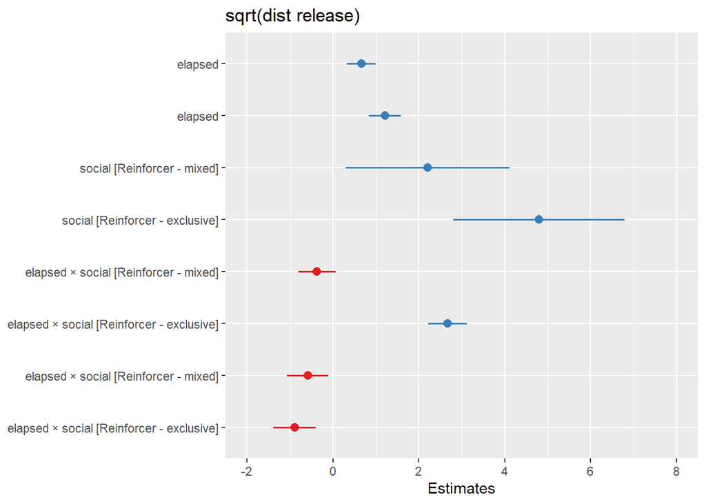

```r
# plot effects
plot_model(best3)
```

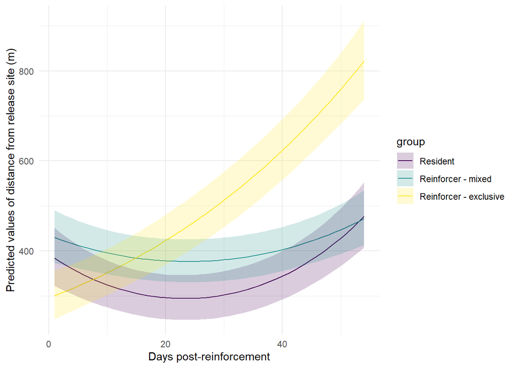

```r
# marginal effects
pred3 <- predict_response(best3, terms = c("elapsed [all]", "social"))

# plot predictions
ggplot(pred3, aes(x, predicted, fill = group, ymin = conf.low, ymax = conf.high)) +
  geom_line(aes(colour = group))+
  geom_ribbon(alpha = 0.2)+
  xlab("Days post-reinforcement") +
  ylab("Predicted values of distance from release site (m)") +
  theme_minimal()+
  scale_fill_viridis_d()+
  scale_colour_viridis_d()
```

**Results:** The best fitting model included social group and time (linear and quadratic), the interaction between these, and individual as a random effect.

Distance from the release site significantly increased over time (estimate: 0.6600 ± 0.1704, p = 0.0001) and had a positive quadratic effect, indicating an acceleration of this increase (estimate: 1.2086 ± 0.1883, p < 0.0001). Mixed reinforcers did not differ from residents in the rate of increase.

**Interpretation:** Mixed reinforcers had greater release site fidelity than exclusive reinforcers. Tactically, site fidelity is importancde because, first, hyperdispersal increases chance of predation, and second, the release area has suitable resources for long-term survival and recruitment.

An alternative explanation is that the exclusive birds were pushed away e.g. due to territoriality or population capacity- but I don’t think this is the case because they continued to have interactions with the other group including some time roosting in the central woodland.

#### Release site fidelity map

How do they move away from the release site over time

[figure not shown]

```r
# Google API key for ggmaps
ggmap::register_google(key = readChar("apikey_google.txt", nchars = file.info("apikey_google.txt")$size))

# Background map MR zones 1 and 2
map_z14 <- get_map(c(144.4380, -37.9000), zoom=14, maptype = "satellite")
map_z15 <- get_map(c(144.4380, -37.9000), zoom=15, maptype = "satellite")

# Metadata - translocation information
metadata  <- read.csv("data/metadata.csv") %>%
  clean_names() %>%
  rename(id = identity,
         mortality = mortality_or_capture) %>%
  mutate(start_date = as_date(dmy(start_date)),
         end_date = as_date(dmy(end_date)),
         mortality = as_date(dmy(mortality)))

# Define fence polygons (zones 1 and 2)
mtr <- rbind(
  ## zone 1
  c(-37.897319, 144.429048), # S end of NW diagonal
  c(-37.894066, 144.432334), # N end of NW diagonal, i.e. NW corner
  c(-37.894749, 144.438305), # bend at main gate
  c(-37.894693, 144.438324), # main gate
  c(-37.894803, 144.439214), # bend before N Z1/2 gate
  c(-37.894718, 144.439337), # N Z1/2 gate, i.e. NE corner
  ## zone 2
  c(-37.892433, 144.440236), # N boundary internal aviary/Z2 i.e. NW corner
  c(-37.892803, 144.443374), # Z2 northern boundary bend 1
  c(-37.893634, 144.444076), # Z2 northern boundary bend 2
  c(-37.894585, 144.447739), # N end of Z2/Z3 boundary, i.e. NE corner
  c(-37.896515, 144.446789), # Z2/Z3 boundary bend 1
  c(-37.896726, 144.446099), # Z2/Z3 boundary bend 2
  c(-37.897964, 144.445706), # Z2/Z3 boundary bend 3
  c(-37.899960, 144.444517), # S end of Z2/Z3 boundary, i.e. SE corner
  c(-37.899908, 144.444288), # Z2/btrw NE corner
  c(-37.898280, 144.440662), # Z1/btrw pen NW corner
  ## zone 1
  c(-37.900692, 144.440368), # Z1/btrw SW corner
  c(-37.902610, 144.443002), # Z1/btrw SE corner
  c(-37.909538, 144.439648), # Z1 SE corner
  c(-37.908999, 144.434965), # Z1 southern boundary bend 1
  c(-37.907537, 144.433359), # Z1 southern boundary bend 2
  c(-37.905958, 144.430140), # Z1 southern boundary bend 3
  c(-37.905486, 144.429479), # Z1 southern boundary bend 4
  c(-37.904649, 144.427566), # Z1 SW corner
  c(-37.897319, 144.429048)  # S end of NW diagonal
  ) %>%  vect(type = "polygons", crs = "EPSG:4326") %>%
  # transpose
  t() %>%
  # add a buffer for GPS accuracy of 30m for analysis, and 10m for mapping
  buffer(10)

ggmap(map_z15)+
  # plot roosts colour by time
  geom_point(aes(longitude, latitude, colour = date),
             size = 2, data = datam2, inherit.aes = FALSE)+
  # add release location
  geom_point(aes(144.434323, -37.902374),
             colour = "white", size = 5, shape = 13, inherit.aes = FALSE)+
  # add fence
  geom_spatvector(data = mtr, inherit.aes = FALSE, fill = NA, colour = "white",
                  linetype = "longdash")+
  # wrap by period
  facet_wrap(~social)+
  # theme options
  scale_colour_viridis_c(trans = "date", name = "2023")+
  theme_void()+
  scale_y_continuous(expand = expansion(mult = c(0, 0.01)))+
  theme(legend.position="bottom",
        legend.key.width = unit(3, 'cm'),
        strip.text = element_text(size = 13))+
  # add north in just the resident facet panel
  annotation_north_arrow(data  = subset(datam2, social == "Resident"),
                         location = "tr",
                         height = unit(0.8, "cm"), width = unit(0.7, "cm"),
                         style = north_arrow_orienteering(text_col = "black"))+
  # add scale bar in just the resident facet panel
  annotation_scale(data  = subset(datam2, social == "Resident"),
                   location = "br", text_col = "black",
                   pad_x = unit(0.1, "cm"), pad_y = unit(0.4, "cm"))
```

### m4: Home range size

Does home range size differ between the social groups?

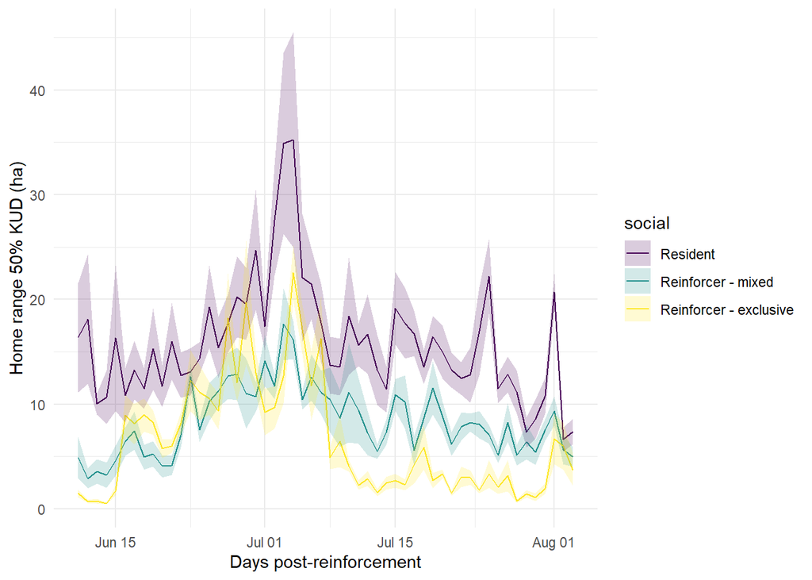

```r
# read in data and filter to reinforcement period
datam4 <- read.csv("results/daily_hr_area.csv") %>%
  # add metadata
  left_join(dplyr::select(metadata, c("id", "cohort"))) %>%
  # format dates as dates
  mutate(date = as_date(date)) %>%
  # limit to reinforcement period
  filter(date %in% rein_dates) %>%
  # add a time elapsed post-release variable
  mutate(elapsed = as.numeric(date - as_date("2023-06-10"))) %>%
  # add column for membership to social group
  mutate(social = ifelse(id %in% club, "Reinforcer - exclusive", ifelse(cohort == "Resident", "Resident", "Reinforcer - mixed"))) %>%
  # convert group to factor and set resident as the intercept
  mutate(social = factor(social, levels = c("Resident", "Reinforcer - mixed", "Reinforcer - exclusive")))

# create social group means
sum4 <- datam4 %>%
  group_by(date, social) %>%
  summarise(dist = mean(area),
            upper = dist + std.error(area),
            lower = dist - std.error(area)) %>%
  arrange(date)

# plot homer range size over time as social group means
ggplot(sum4, aes(date, dist, ymin = lower, ymax = upper)) +
  geom_path(aes(colour = social)) +
  geom_ribbon(aes(fill = social), alpha = 0.2) +
  xlab("Days post-reinforcement") +
  ylab("Home range 50% KUD (ha)") +
  theme_minimal() +
  scale_fill_viridis_d()+
  scale_colour_viridis_d()
```

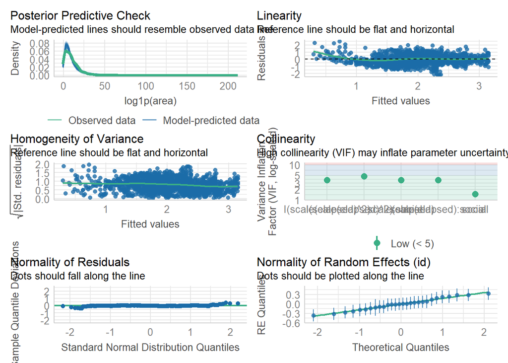

```r
# test difference between the groups with interaction of time as a quadratic
m4 <- glmmTMB(log1p(area) ~ social * (scale(elapsed) + I(scale(elapsed)^2))+ (1|id),
              data = datam4,
              na.action = "na.fail")

# model selection
dm4 <- dredge(m4)

# parsimonious model where delta <2 and fewest predictors
# in this case there was only one model (the top ranked) with delta <2
best4 <- get.models(dm4, delta==0)[[1]]

# check model
check_model(best4)
```

```r
# summary
summary(best4)
```

```
##  Family: gaussian  ( identity )
## Formula:
## log1p(area) ~ scale(elapsed) + I(scale(elapsed)^2) + social +
##     (1 | id) + scale(elapsed):social + I(scale(elapsed)^2):social
## Data: datam4
##
##      AIC      BIC   logLik deviance df.resid
##   2942.6   3000.7  -1460.3   2920.6     1447
##
## Random effects:
##
## Conditional model:
##  Groups   Name        Variance Std.Dev.
##  id       (Intercept) 0.03953  0.1988
##  Residual             0.41953  0.6477
## Number of obs: 1458, groups:  id, 28
##
## Dispersion estimate for gaussian family (sigma^2): 0.42
##
## Conditional model:
##                                                  Estimate Std. Error z value
## (Intercept)                                       2.86330    0.08712   32.87
## scale(elapsed)                                   -0.04594    0.03292   -1.40
## I(scale(elapsed)^2)                              -0.20688    0.03661   -5.65
## socialReinforcer - mixed                         -0.56176    0.11311   -4.97
## socialReinforcer - exclusive                     -0.87251    0.11800   -7.39
## scale(elapsed):socialReinforcer - mixed           0.14596    0.04282    3.41
## scale(elapsed):socialReinforcer - exclusive      -0.17492    0.04416   -3.96
## I(scale(elapsed)^2):socialReinforcer - mixed     -0.09518    0.04748   -2.00
## I(scale(elapsed)^2):socialReinforcer - exclusive -0.17040    0.04919   -3.46
##                                                  Pr(>|z|)
## (Intercept)                                       < 2e-16 ***
## scale(elapsed)                                   0.162832
## I(scale(elapsed)^2)                              1.59e-08 ***
## socialReinforcer - mixed                         6.83e-07 ***
## socialReinforcer - exclusive                     1.43e-13 ***
## scale(elapsed):socialReinforcer - mixed          0.000654 ***
## scale(elapsed):socialReinforcer - exclusive      7.46e-05 ***
## I(scale(elapsed)^2):socialReinforcer - mixed     0.045022 *
## I(scale(elapsed)^2):socialReinforcer - exclusive 0.000532 ***
## ---
## Signif. codes:  0 '***' 0.001 '**' 0.01 '*' 0.05 '.' 0.1 ' ' 1
```

```r
# post-hoc comparison of means
emmeans(best4, pairwise ~ social, type = "response")
```

```
## $emmeans
##  social                 response SE df asymp.LCL asymp.UCL
##  Resident                 nonEst NA NA        NA        NA
##  Reinforcer - mixed       nonEst NA NA        NA        NA
##  Reinforcer - exclusive   nonEst NA NA        NA        NA
##
## Confidence level used: 0.95
## Intervals are back-transformed from the log1p scale
##
## $contrasts
##  contrast                                        estimate    SE   df t.ratio
##  Resident - (Reinforcer - mixed)                    0.562 0.113 1447   4.966
##  Resident - (Reinforcer - exclusive)                0.873 0.118 1447   7.394
##  (Reinforcer - mixed) - (Reinforcer - exclusive)    0.311 0.107 1447   2.893
##  p.value
##   <.0001
##   <.0001
##   0.0108
##
## Note: contrasts are still on the log1p scale. Consider using
##       regrid() if you want contrasts of back-transformed estimates.
## P value adjustment: tukey method for comparing a family of 3 estimates
```

```r
# post-hoc comparison of slopes
emtrends(best4, pairwise ~ social, var = "elapsed")
```

```
## $emtrends
##  social                 elapsed.trend      SE   df lower.CL upper.CL
##  Resident                    -0.00295 0.00211 1447 -0.00709  0.00120
##  Reinforcer - mixed           0.00642 0.00176 1447  0.00297  0.00987
##  Reinforcer - exclusive      -0.01417 0.00189 1447 -0.01788 -0.01047
##
## Confidence level used: 0.95
##
## $contrasts
##  contrast                                        estimate      SE   df t.ratio
##  Resident - (Reinforcer - mixed)                 -0.00937 0.00275 1447  -3.408
##  Resident - (Reinforcer - exclusive)              0.01122 0.00283 1447   3.961
##  (Reinforcer - mixed) - (Reinforcer - exclusive)  0.02059 0.00258 1447   7.980
##  p.value
##   0.0019
##   0.0002
##   <.0001
##
## P value adjustment: tukey method for comparing a family of 3 estimates
```

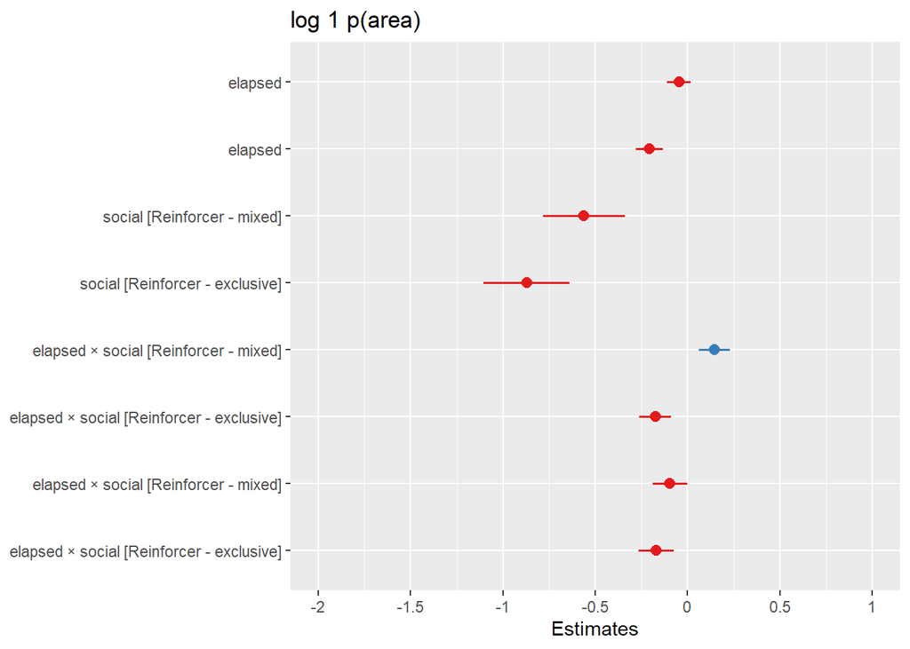

```r
# plot effects
plot_model(best4)
```

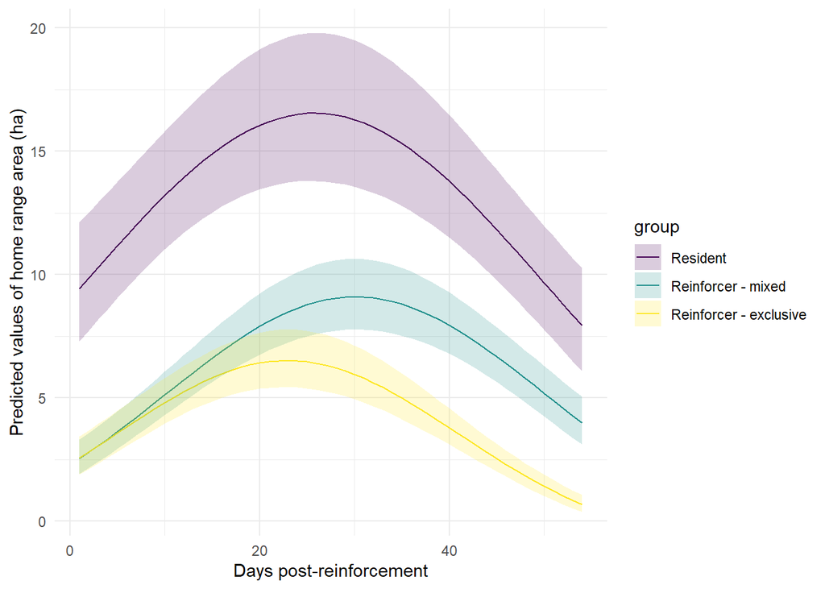

```r
# marginal effects
pred4 <- predict_response(best4, terms = c("elapsed [all]", "social"))

# plot predictions
ggplot(pred4, aes(x, predicted, fill = group, ymin = conf.low, ymax = conf.high)) +
  geom_line(aes(colour = group))+
  geom_ribbon(alpha = 0.2)+
  xlab("Days post-reinforcement") +
  ylab("Predicted values of home range area (ha)") +
  theme_minimal()+
  scale_fill_viridis_d()+
  scale_colour_viridis_d()
```

**Results:** The best fitting model included social group and time (linear and quadratic), the interaction between these, and individual as a random effect.

No linear effect (i.e. no increase over time). However, the quadratic term is significant and negative (estimate: -0.20688 ± 0.0366, p < 0.001) i.e., an initial increase followed by a decrease, although the trend over time varies across social groups. The mixed reinforcers show a slight deceleration (-0.095, p = 0.045) and the exclusive reinforcers show a stronger deceleration (-0.17, p < 0.001) compared to residents. Exclusive reinforcers decrease home range size singificatly more than both other groups (p < 0.0002).

All groups have significantly different home range size.

**Interpretation:** Stabilising home range area (significant negative quadratic term) indicates progression along establishment occurs for both groups - this is similar to roost site fidelity, showing exploration then contraction.

Exclusive reinforcers have the smallest home ranges, perhaps related to distance moved - they decline their home range size significantly more than mixed reinforcers. Mixed reinforcers may be benefiting from habitat cues, prompting them to explore more, or from perceived safety being in the larger group.

### m5: Time budget

Does time allocated to foraging differ between the social groups?

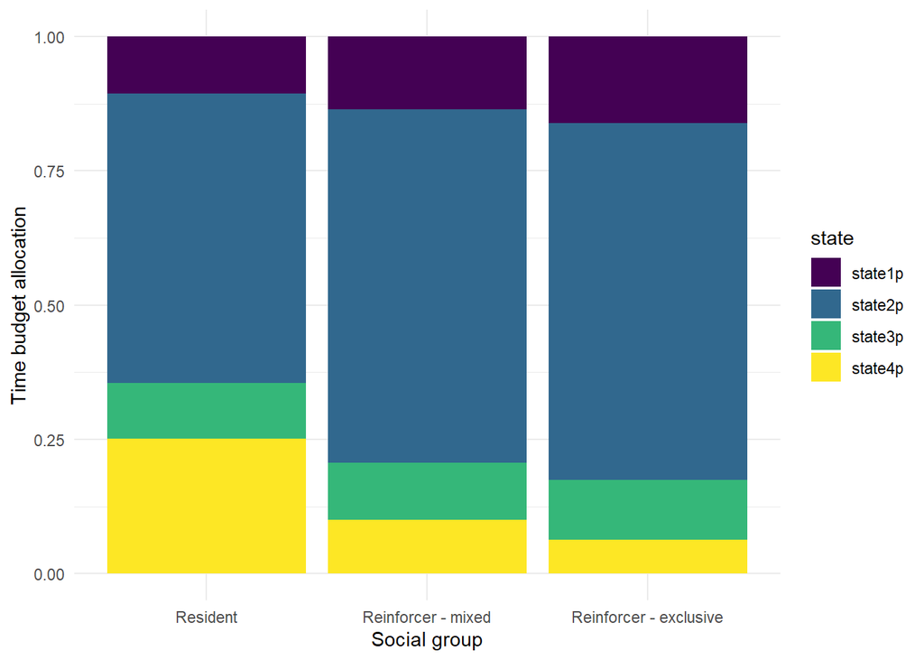

```r
# read in data and filter to reinforcement period
datam5 <- read.csv("results/daily_time_budget.csv") %>%
  # add metadata
  left_join(dplyr::select(metadata, c("id", "cohort"))) %>%
  # format dates as dates
  mutate(date = as_date(date_bird)) %>%
  # limit to reinforcement period
  filter(date %in% rein_dates) %>%
  # add a time elapsed post-release variable
  mutate(elapsed = as.numeric(date - as_date("2023-06-10"))) %>%
  # add column for membership to social group
  mutate(social = ifelse(id %in% club, "Reinforcer - exclusive", ifelse(cohort == "Resident", "Resident", "Reinforcer - mixed"))) %>%
  # convert group to factor and set resident as the intercept
  mutate(social = factor(social, levels = c("Resident", "Reinforcer - mixed", "Reinforcer - exclusive")))

# create social group means
sum5 <- datam5 %>%
  group_by(date, social) %>%
  summarise(dist = mean(state2p),
            upper = dist + std.error(state2p),
            lower = dist - std.error(state2p)) %>%
  arrange(date)

# and pivot longer for barchart
datam5bar <- datam5 %>%
  select(!3:7) %>%
  pivot_longer(3:6, names_to = "state", values_to = "proportion")

# plot time budget by social group
ggplot(datam5bar)+
  geom_bar(aes(x = social, y = proportion, fill = state),
           position="fill", stat="identity")+
  xlab("Social group")+
  ylab("Time budget allocation")+
  theme_minimal()+
  scale_fill_viridis_d()
```

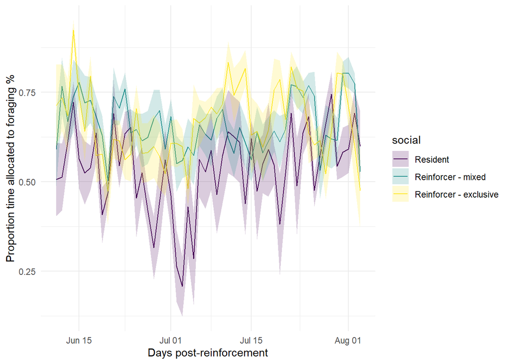

```r
# plot foraging allocation over time as social group means
ggplot(sum5, aes(date, dist, ymin = lower, ymax = upper)) +
  geom_path(aes(colour = social)) +
  geom_ribbon(aes(fill = social), alpha = 0.2) +
  xlab("Days post-reinforcement") +
  ylab("Proportion time allocated to foraging %") +
  theme_minimal() +
  scale_fill_viridis_d()+
  scale_colour_viridis_d()
```

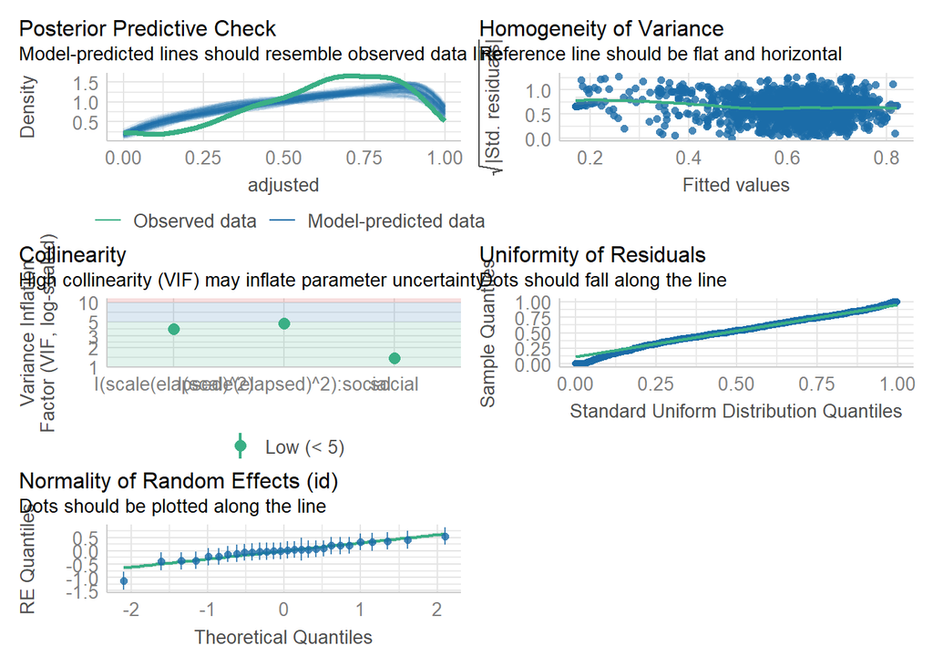

```r
# Adjust values slightly so that 0 < x < 1
datam5 <- datam5 %>%
  mutate(adjusted = (state2p + 0.001) / 1.002)

# test difference between the groups with interaction of time as a quadratic
m5 <- glmmTMB(adjusted ~ social * (scale(elapsed) + I(scale(elapsed)^2)) + (1|id),
              data = datam5,
              family = beta_family(link = "logit"),
              na.action = "na.fail")

# model selection
dm5 <- dredge(m5)

# parsimonious model where delta <2 and fewest predictors
# in this case the second model had delta AICc of 1 and 2 fewer predictors
best5 <- get.models(dm5, delta<2)[[2]]

# check model
check_model(best5)
```

```r
# summary
summary(best5)
```

```
##  Family: beta  ( logit )
## Formula:
## adjusted ~ I(scale(elapsed)^2) + social + (1 | id) + I(scale(elapsed)^2):social
## Data: datam5
##
##      AIC      BIC   logLik deviance df.resid
##   -506.2   -463.9    261.1   -522.2     1448
##
## Random effects:
##
## Conditional model:
##  Groups Name        Variance Std.Dev.
##  id     (Intercept) 0.1178   0.3432
## Number of obs: 1456, groups:  id, 28
##
## Dispersion parameter for beta family (): 2.96
##
## Conditional model:
##                                                  Estimate Std. Error z value
## (Intercept)                                      -0.44956    0.14401  -3.122
## I(scale(elapsed)^2)                               0.34810    0.05828   5.973
## socialReinforcer - mixed                          0.84295    0.18788   4.487
## socialReinforcer - exclusive                      1.00076    0.19604   5.105
## I(scale(elapsed)^2):socialReinforcer - mixed     -0.15862    0.07486  -2.119
## I(scale(elapsed)^2):socialReinforcer - exclusive -0.20451    0.07669  -2.667
##                                                  Pr(>|z|)
## (Intercept)                                       0.00180 **
## I(scale(elapsed)^2)                              2.33e-09 ***
## socialReinforcer - mixed                         7.24e-06 ***
## socialReinforcer - exclusive                     3.31e-07 ***
## I(scale(elapsed)^2):socialReinforcer - mixed      0.03410 *
## I(scale(elapsed)^2):socialReinforcer - exclusive  0.00766 **
## ---
## Signif. codes:  0 '***' 0.001 '**' 0.01 '*' 0.05 '.' 0.1 ' ' 1
```

```r
# post-hoc comparison of means
emmeans(best5, pairwise ~ social, type = "response")
```

```
## $emmeans
##  social                 response SE df asymp.LCL asymp.UCL
##  Resident                 nonEst NA NA        NA        NA
##  Reinforcer - mixed       nonEst NA NA        NA        NA
##  Reinforcer - exclusive   nonEst NA NA        NA        NA
##
## Confidence level used: 0.95
## Intervals are back-transformed from the logit scale
##
## $contrasts
##  contrast                                        odds.ratio     SE  df null
##  Resident / (Reinforcer / mixed)                      0.430 0.0809 Inf    1
##  Resident / (Reinforcer / exclusive)                  0.368 0.0721 Inf    1
##  (Reinforcer / mixed) / (Reinforcer / exclusive)      0.854 0.1530 Inf    1
##  z.ratio p.value
##   -4.487  <.0001
##   -5.105  <.0001
##   -0.880  0.6527
##
## P value adjustment: tukey method for comparing a family of 3 estimates
## Tests are performed on the log odds ratio scale
```

```r
# post-hoc comparison of slopes
emtrends(best5, pairwise ~ social, var = "elapsed")
```

```
## $emtrends
##  social                 elapsed.trend       SE  df asymp.LCL asymp.UCL
##  Resident                   -1.47e-12 2.46e-13 Inf -1.95e-12 -9.86e-13
##  Reinforcer - mixed         -7.99e-13 1.99e-13 Inf -1.19e-12 -4.09e-13
##  Reinforcer - exclusive     -6.05e-13 2.10e-13 Inf -1.02e-12 -1.93e-13
##
## Confidence level used: 0.95
##
## $contrasts
##  contrast                                         estimate       SE  df z.ratio
##  Resident - (Reinforcer - mixed)                 -6.69e-13 3.16e-13 Inf  -2.119
##  Resident - (Reinforcer - exclusive)             -8.62e-13 3.23e-13 Inf  -2.667
##  (Reinforcer - mixed) - (Reinforcer - exclusive) -1.93e-13 2.89e-13 Inf  -0.669
##  p.value
##   0.0860
##   0.0209
##   0.7817
##
## P value adjustment: tukey method for comparing a family of 3 estimates
```

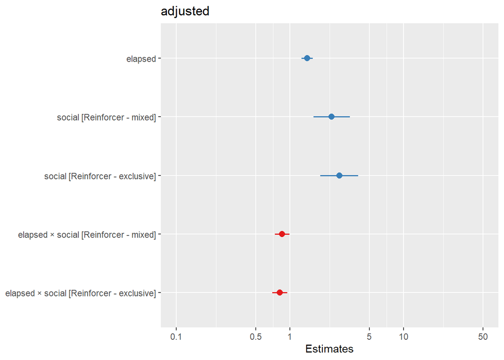

```r
# plot effects
plot_model(best5)
```

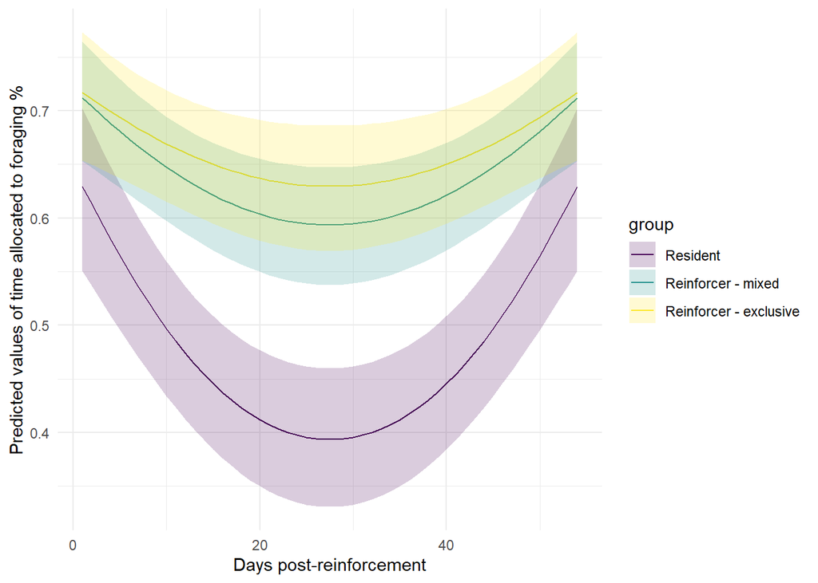

```r
# marginal effects
pred5 <- predict_response(best5, terms = c("elapsed [all]", "social"),
                          bias_correction = TRUE)

# plot predictions
ggplot(pred5, aes(x, predicted, fill = group, ymin = conf.low, ymax = conf.high)) +
  geom_line(aes(colour = group))+
  geom_ribbon(alpha = 0.2)+
  xlab("Days post-reinforcement") +
  ylab("Predicted values of time allocated to foraging %") +
  theme_minimal()+
  scale_fill_viridis_d()+
  scale_colour_viridis_d()
```

**Results:** The best fitting model included social group and time (quadratic only), the interaction between social group and the quadratic, and individual as a random effect.

The reinforcer groups (both mixed and exclusive) are more likely to exhibit higher foraging allocation (mean 64% for mixed and 67% for exclusive) than the residents (mean 47%, p < 0.0001). The reinforcers did not differ from one another.

Linear time was not included in the model - instead a significant positive quadratic effect.The quadratic effect was significantly less for reinforcers than residents (p < 0.034).

**Interpretation:** Both reinforcers have higher allocations than the residents, probably because residents have overall better foraging efficiency.

The quadratic trend may be associated with seasonal food availability.

### m6: Weight change

In addition to the movement-based metrics of performance I wanted to look at health check data. Weight change post-release is a good indicator of performance, where some loss is expected but less steep decline (trending towards stability) indicates better performance.

We were unable to compare residents to reinforcers for weight change because we did not have weight measurements for the six individuals released in January 2023 (backpacks fitted in the December trip and released by Mt Rothwell staff rather than me going back down there). So we can only compare reinforcers, but interested to see how the social group memberships contrast.

Unlike the movement data, the study period is for 70 days because weights were taken after the 55 minimum common tracking period.

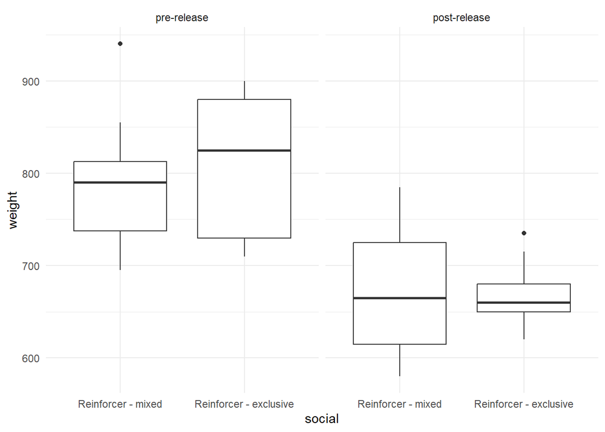

```r
# read in data and clean up
datam6 <- read_xlsx("data/healthchecks.xlsx") %>%
  clean_names() %>%
  rename(id = identity) %>%
  select(id, date, weight) %>%
  # add metadata
  left_join(select(metadata, c(id, start_date, cohort))) %>%
  drop_na() %>%
  # format dates
  mutate(date = as_date(date),
         start_date = as_date(start_date)) %>%
  # calculate elapsed time and add status
  mutate(elapsed = as.numeric(date - start_date)) %>%
  # keep only reinforcers
  filter(cohort == "Reinforcing") %>%
  # add social group membership %>%
   mutate(social = as_factor(ifelse(id %in% club, "Reinforcer - exclusive", ifelse(cohort == "Resident", "Resident", "Reinforcer - mixed")))) %>%
  # keep only the latest pre-release values and assign to pre/post release
  group_by(id) %>%
  filter(elapsed > 0 | elapsed == max(elapsed[elapsed <= 0])) %>%
  ungroup() %>%
  mutate(status = as_factor(ifelse(elapsed > 0, "post-release", "pre-release"))) %>%
  arrange(id) %>%
  # filter to study period
  filter(elapsed <70)

# plot weight pre and post-release
ggplot(datam6)+
  geom_boxplot(aes(social, weight))+
  theme_minimal()+
  facet_wrap(~status)
```

We have pre and post data for 18 of the 20 reinforcers. All lost weight. The mixed social group started out on average lower than the exclusive group.

Next I calculated the change in weight both in grams and as a proportion of starting weight (to account for variation in body sizes).

```r
# calculate weight change in grams and as a proportion of starting weight
sum6 <- datam6 %>%
  select(c(id, social, weight, status)) %>%
  pivot_wider(names_from = status, values_from = weight) %>%
  clean_names() %>%
  drop_na() %>%
  # add change columns
  mutate(diff = pre_release - post_release,
         proportion = diff/pre_release) %>%
  # format social group as factor
  mutate(social = as_factor(social))
```

Although total weight change seems on average lower in the mixed group, proportionally it does not look like a lot of difference.

```r
# test whether weight change differs between the social groups
# as total difference
m6a <- glmmTMB(diff ~ social, data = sum6)
summary(m6a)
```

```
##  Family: gaussian  ( identity )
## Formula:          diff ~ social
## Data: sum6
##
##      AIC      BIC   logLik deviance df.resid
##    202.5    205.2    -98.2    196.5       15
##
##
## Dispersion estimate for gaussian family (sigma^2): 3.22e+03
##
## Conditional model:
##                              Estimate Std. Error z value Pr(>|z|)
## (Intercept)                    123.33      18.92   6.518 7.12e-11 ***
## socialReinforcer - exclusive    16.67      26.76   0.623    0.533
## ---
## Signif. codes:  0 '***' 0.001 '**' 0.01 '*' 0.05 '.' 0.1 ' ' 1
```

```r
# and as a proportion of starting weight
m6b <- glmmTMB(proportion ~ social, data = sum6)
summary(m6b)
```

```
##  Family: gaussian  ( identity )
## Formula:          proportion ~ social
## Data: sum6
##
##      AIC      BIC   logLik deviance df.resid
##    -43.4    -40.7     24.7    -49.4       15
##
##
## Dispersion estimate for gaussian family (sigma^2): 0.00377
##
## Conditional model:
##                              Estimate Std. Error z value Pr(>|z|)
## (Intercept)                   0.15302    0.02046   7.478 7.54e-14 ***
## socialReinforcer - exclusive  0.01542    0.02894   0.533    0.594
## ---
## Signif. codes:  0 '***' 0.001 '**' 0.01 '*' 0.05 '.' 0.1 ' ' 1
```

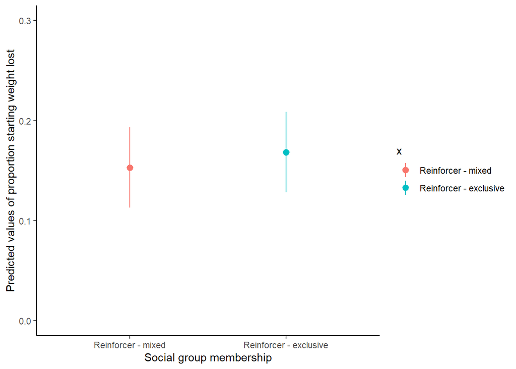

```r
# predictions
pred6b <- predict_response(m6b, terms = c("social"))

# plot predictions
ggplot(pred6b, aes(x, predicted, colour = x))+
  geom_pointrange(aes(ymin = conf.low, ymax = conf.high))+
  xlab("Social group membership") +
  ylab("Predicted values of proportion starting weight lost")+
  theme_classic()+
  scale_y_continuous(limits = c(0, 0.3))
```

There is no significant differences between groups for weight loss.

I want to model predicted effects of overall weight change so I can model a geom_line of pre and post translocation (I think the geom_pointrange looks boring).

```r
# weight change over time between social groups
m6 <- glmmTMB(weight ~ social * status, data = datam6)
summary(m6)
```

```
##  Family: gaussian  ( identity )
## Formula:          weight ~ social * status
## Data: datam6
##
##      AIC      BIC   logLik deviance df.resid
##    433.2    441.4   -211.6    423.2       33
##
##
## Dispersion estimate for gaussian family (sigma^2): 4.02e+03
##
## Conditional model:
##                                                 Estimate Std. Error z value
## (Intercept)                                       785.91      19.13   41.09
## socialReinforcer - exclusive                       24.65      28.51    0.86
## statuspost-release                               -108.69      28.51   -3.81
## socialReinforcer - exclusive:statuspost-release   -31.31      41.31   -0.76
##                                                 Pr(>|z|)
## (Intercept)                                      < 2e-16 ***
## socialReinforcer - exclusive                    0.387318
## statuspost-release                              0.000138 ***
## socialReinforcer - exclusive:statuspost-release 0.448501
## ---
## Signif. codes:  0 '***' 0.001 '**' 0.01 '*' 0.05 '.' 0.1 ' ' 1
```

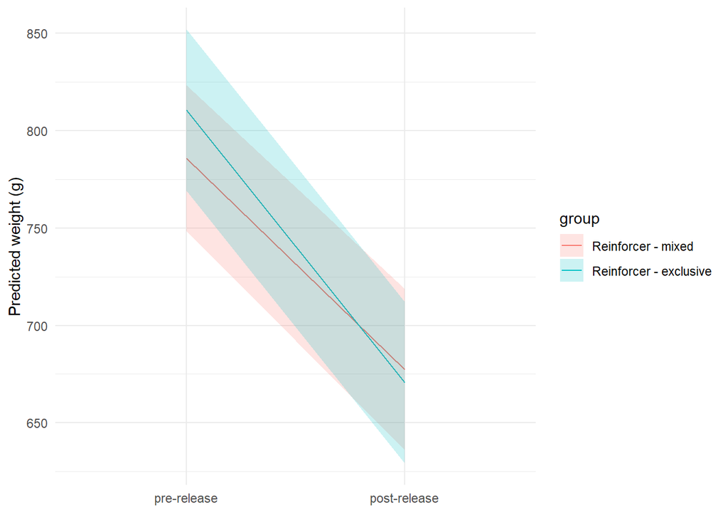

```r
# predictions
pred6 <- predict_response(m6, terms = c("status", "social"))

# plot predictions
ggplot(pred6, aes(x, predicted, fill = group, ymin = conf.low, ymax = conf.high, group = group)) +
  geom_line(aes(colour = group))+
  geom_ribbon(alpha = 0.2)+
  xlab(element_blank())+
  ylab("Predicted weight (g)") +
  theme_minimal()
```

Significant effect of status (pre and post release) No difference between groups.

## Figures

Multi-plot of predicted values for all PRBM metrics by social group over time.

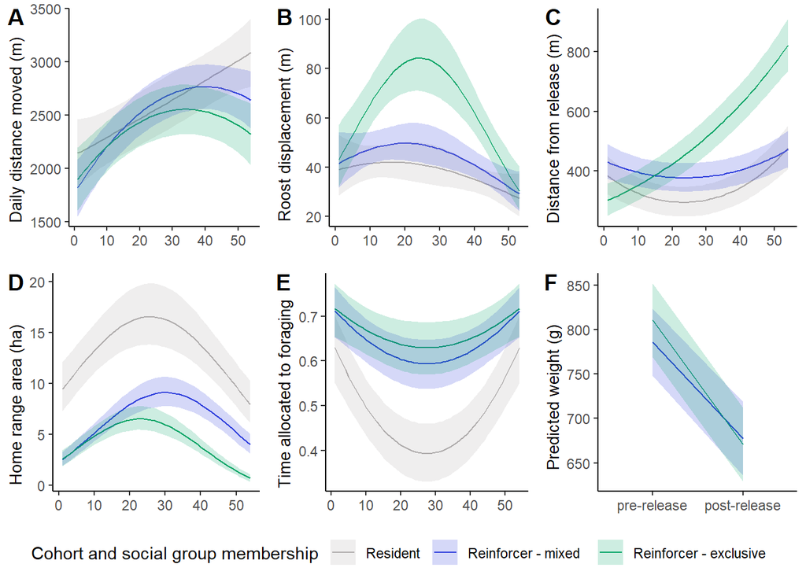

```r
# set default theme options for all plots
pal <- c("#AFACAC","#2E3EDC", "#07A567")

theme <- function(){
  list(
    geom_line(aes(colour = group)),
    geom_ribbon(alpha = 0.2),
    xlab(element_blank()),
    scale_x_continuous(breaks=seq(0, 50, 10)),
    theme_classic(),
    ggplot2::theme(axis.title.y = element_text(hjust = 0.1, size = 10)),
    scale_color_manual(values = pal,
                       name = "Cohort and social group membership"),
    scale_fill_manual(values = pal,,
                      name = "Cohort and social group membership")
  )
}

# list of plots
g1 <- ggplot(pred1, aes(x, predicted, fill = group, ymin = conf.low, ymax = conf.high)) +
  xlab("Days post-reinforcement") +
  ylab("Daily distance moved (m)")+
  theme()

g2 <- ggplot(pred2, aes(x, predicted, fill = group, ymin = conf.low, ymax = conf.high)) +
  xlab("Days post-reinforcement") +
  ylab("Roost displacement (m)")+
  theme()

g3 <- ggplot(pred3, aes(x, predicted, fill = group, ymin = conf.low, ymax = conf.high)) +
  xlab("Days post-reinforcement") +
  ylab("Distance from release (m)")+
  theme()

g4 <- ggplot(pred4, aes(x, predicted, fill = group, ymin = conf.low, ymax = conf.high)) +
  xlab("Days post-reinforcement") +
  ylab("Home range area (ha)")+
  theme()

g5 <- ggplot(pred5, aes(x, predicted, fill = group, ymin = conf.low, ymax = conf.high)) +
  xlab("Days post-reinforcement") +
  ylab("Time allocated to foraging")+
  theme()

g6 <- ggplot(pred6, aes(x, predicted, fill = group,
                        ymin = conf.low, ymax = conf.high, group = group)) +
  geom_line(aes(colour = group))+
  geom_ribbon(alpha = 0.2)+
  theme_classic()+
  xlab(element_blank())+
  ylab("Predicted weight (g)") +
  scale_colour_manual(values = c("#2E3EDC", "#07A567"))+
  scale_fill_manual(values = c("#2E3EDC", "#07A567"))+
  ggplot2::theme(axis.title.y = element_text(hjust = 0.3, size = 10))

# multi plot 3x2
ggarrange(g1, g2, g3, g4, g5, g6,
          ncol = 3, nrow = 2,
          labels = c("A", "B", "C", "D", "E", "F"),
          common.legend = TRUE, legend = "bottom")
```

Multi plot of all effects.

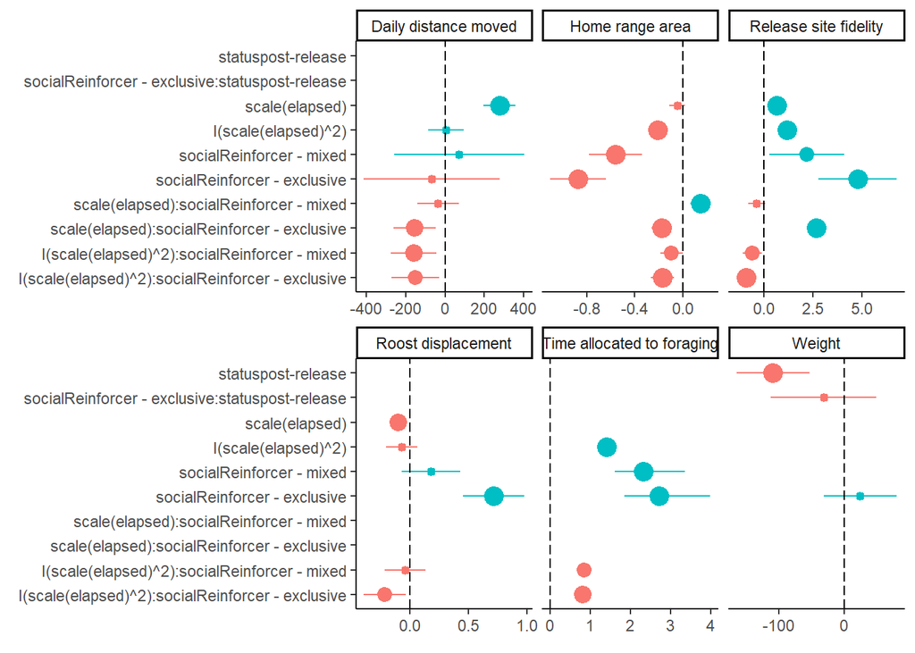

```r
# effects
e1 <- plot_model(best1)[["data"]] %>%
  mutate(variable = "Daily distance moved")

e2 <- plot_model(best2)[["data"]] %>%
  mutate(variable = "Roost displacement")

e3 <- plot_model(best3)[["data"]] %>%
  mutate(variable = "Release site fidelity")

e4 <- plot_model(best4)[["data"]] %>%
  mutate(variable = "Home range area")

e5 <- plot_model(best5)[["data"]] %>%
  mutate(variable = "Time allocated to foraging")

e6 <- plot_model(m6)[["data"]] %>%
  mutate(variable = "Weight")

# combine effects
effects <- rbind(e1, e2, e3, e4, e5, e6) %>%
  # add column for point size by strength of evidence (p values)
  mutate(strength  = ifelse(p.stars == "*", 2,
                            ifelse(p.stars == "**", 3,
                                   ifelse(p.stars == "***", 4, 1))))

# plot effects
ggplot(effects)+
  geom_pointrange(aes(estimate, term,
                      xmin = conf.low, xmax = conf.high,
                      size = strength, colour = group),
                  show.legend = FALSE)+
  geom_vline(xintercept=c(0), linetype="longdash")+
  facet_wrap(~variable, scales = "free_x")+
  scale_size_continuous(range = c(0.3, 1))+
  xlab(element_blank())+
  ylab(element_blank())+
  theme_classic()
```